# EDA_task2

```python
Saiket Systems Internship
Task 2:Exploratory Data Analysis (EDA)
Intern: Nku George Ekong
Domain: Data Science
Dataset: Customer Churn Dataset
```

```python
# Data manipulation
import pandas as pd
import numpy as np
# Data Visualization
import matplotlib.pyplot as plt
import seaborn as sns
```

```python
#Loading the Dataset
data = pd.read_csv(r"C:\Users\HomePC\OneDrive\Desktop\saiket_dataset.csv")

data.head()
```

|  | customerID | gender | SeniorCitizen | Partner | Dependents | tenure | PhoneService | MultipleLines | InternetService | OnlineSecurity | ... | DeviceProtection | TechSupport | StreamingTV | StreamingMovies | Contract | PaperlessBilling | PaymentMethod | MonthlyCharges | TotalCharges | Churn |
| --- | --- | --- | --- | --- | --- | --- | --- | --- | --- | --- | --- | --- | --- | --- | --- | --- | --- | --- | --- | --- | --- |
| 0 | 7590-VHVEG | Female | 0 | Yes | No | 1 | No | No phone service | DSL | No | ... | No | No | No | No | Month-to-month | Yes | Electronic check | 29.85 | 29.85 | No |
| 1 | 5575-GNVDE | Male | 0 | No | No | 34 | Yes | No | DSL | Yes | ... | Yes | No | No | No | One year | No | Mailed check | 56.95 | 1889.5 | No |
| 2 | 3668-QPYBK | Male | 0 | No | No | 2 | Yes | No | DSL | Yes | ... | No | No | No | No | Month-to-month | Yes | Mailed check | 53.85 | 108.15 | Yes |
| 3 | 7795-CFOCW | Male | 0 | No | No | 45 | No | No phone service | DSL | Yes | ... | Yes | Yes | No | No | One year | No | Bank transfer (automatic) | 42.30 | 1840.75 | No |
| 4 | 9237-HQITU | Female | 0 | No | No | 2 | Yes | No | Fiber optic | No | ... | No | No | No | No | Month-to-month | Yes | Electronic check | 70.70 | 151.65 | Yes |

5 rows × 21 columns

```python
#checking the data structure
data.shape
data.info()
```

```
<class 'pandas.core.frame.DataFrame'>
RangeIndex: 7043 entries, 0 to 7042
Data columns (total 21 columns):
 #   Column            Non-Null Count  Dtype
---  ------            --------------  -----
 0   customerID        7043 non-null   object
 1   gender            7043 non-null   object
 2   SeniorCitizen     7043 non-null   int64
 3   Partner           7043 non-null   object
 4   Dependents        7043 non-null   object
 5   tenure            7043 non-null   int64
 6   PhoneService      7043 non-null   object
 7   MultipleLines     7043 non-null   object
 8   InternetService   7043 non-null   object
 9   OnlineSecurity    7043 non-null   object
 10  OnlineBackup      7043 non-null   object
 11  DeviceProtection  7043 non-null   object
 12  TechSupport       7043 non-null   object
 13  StreamingTV       7043 non-null   object
 14  StreamingMovies   7043 non-null   object
 15  Contract          7043 non-null   object
 16  PaperlessBilling  7043 non-null   object
 17  PaymentMethod     7043 non-null   object
 18  MonthlyCharges    7043 non-null   float64
 19  TotalCharges      7043 non-null   object
 20  Churn             7043 non-null   object
dtypes: float64(1), int64(2), object(18)
memory usage: 1.1+ MB
```

```python
#Checking for missing values
data.isnull().sum()
```

```
customerID          0
gender              0
SeniorCitizen       0
Partner             0
Dependents          0
tenure              0
PhoneService        0
MultipleLines       0
InternetService     0
OnlineSecurity      0
OnlineBackup        0
DeviceProtection    0
TechSupport         0
StreamingTV         0
StreamingMovies     0
Contract            0
PaperlessBilling    0
PaymentMethod       0
MonthlyCharges      0
TotalCharges        0
Churn               0
dtype: int64
```

```python
#Removing missing values
data = data.dropna()
```

```python
#converting the totalcharges column to numeric
data["TotalCharges"] = pd.to_numeric(data["TotalCharges"], errors="coerce")
```

```python
#Overall churn Rate
churn_rate = data["Churn"].value_counts(normalize=True) * 100

print(churn_rate)
```

```
Churn
No     73.463013
Yes    26.536987
Name: proportion, dtype: float64
```

The results explain that aboutb 26% of customers churn, which represents a moderate customer loss, while ~70%+ are still being retented which shows a good but requires improvements.

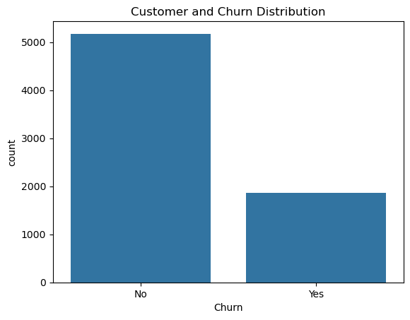

```python
#Visualization:
sns.countplot(x="Churn", data=data)

plt.title("Customer and Churn Distribution")
plt.savefig("Customer and Churn Distribution.png", dpi=200, bbox_inches='tight')
plt.show()
```

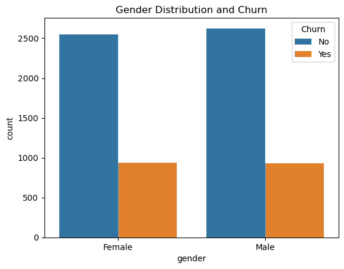

```python
#Gender vs Churn visualization
sns.countplot(x="gender", hue="Churn", data=data)

plt.title("Gender Distribution and Churn")
plt.savefig("Gender Distribution and Churn.png", dpi=200, bbox_inches='tight')
plt.show()
```

The visualization shows a Usually balanced churn rate across gender, which may NOT strongly influence churn.

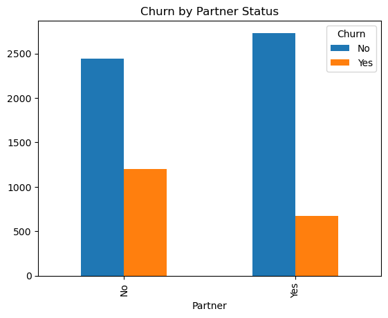

```python
#churn by partner status
pd.crosstab(data['Partner'], data['Churn']).plot(kind='bar')
plt.title("Churn by Partner Status")
plt.show()
```

The visuals show that Customers without partners often churn more. This suggests that stability affects retention.

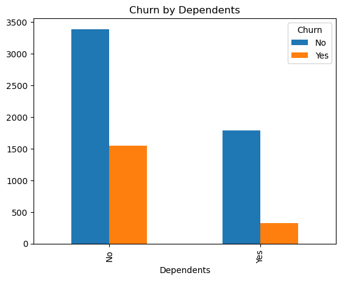

```python
#Churn by Dependents
pd.crosstab(data['Dependents'], data['Churn']).plot(kind='bar')
plt.title("Churn by Dependents")
plt.show()
```

```python
The visuals show that Customers with dependents have a lower churn, which
Indicates a long-term commitment behavior.
```

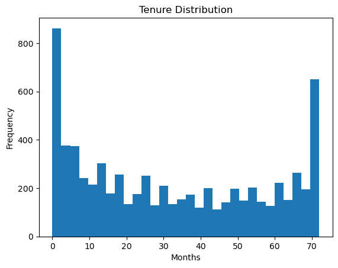

```python
#Tenure Distribution & Churn
data['tenure'].plot(kind='hist', bins=30)
plt.title("Tenure Distribution")
plt.xlabel("Months")
plt.show()
```

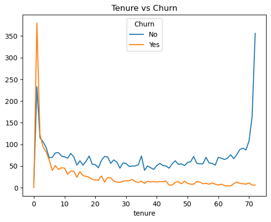

```python
pd.crosstab(data['tenure'], data['Churn']).plot()
plt.title("Tenure vs Churn")
plt.show()
```

The visualizations show that Early months customers who fall within the month-month class have the highest churn, while Customers who stay longer are less likely to leave. A critical observation shows that customers within the first 6–12 months are the danger zone and require immediate attention.

```python
#Churn by contract type
pd.crosstab(data['Contract'], data['Churn'], normalize='index') * 100
```

| Churn Contract | No | Yes |
| --- | --- | --- |
| Month-to-month | 57.290323 | 42.709677 |
| One year | 88.730482 | 11.269518 |
| Two year | 97.168142 | 2.831858 |

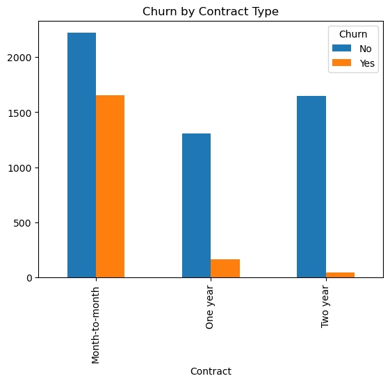

```python
pd.crosstab(data['Contract'], data['Churn']).plot(kind='bar')
plt.title("Churn by Contract Type")
plt.show()
```

These results show that customers who are on a Month-to-month contract exhibit the highest churn, while those on a Two-year contracts show the lowest churn This suggests that Long-term contracts improve customer retention.

```python
#customer churn by Payment Method
pd.crosstab(data['PaymentMethod'], data['Churn'], normalize='index') * 100
```

| Churn PaymentMethod | No | Yes |
| --- | --- | --- |
| Bank transfer (automatic) | 83.290155 | 16.709845 |
| Credit card (automatic) | 84.756899 | 15.243101 |
| Electronic check | 54.714588 | 45.285412 |
| Mailed check | 80.893300 | 19.106700 |

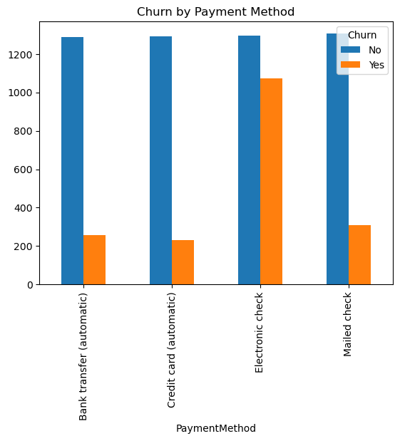

```python
#visualization
pd.crosstab(data['PaymentMethod'], data['Churn']).plot(kind='bar')
plt.title("Churn by Payment Method")
plt.show()
```

```python
The results show that the electronic check method of payment has the highest churn, while
Automatic payments have the least churn
This suggests proper adoption and implementation of auto-payment systems among customers
```

1. Summary

This exploratory data analysis (EDA) was conducted to understand customer behavior and identify patterns associated with customer churn. The primary objective was to analyze the overall churn rate and examine how different customer characteristics—such as gender, partner status, dependents, tenure, contract type, and payment methods—relate to churn. The insights derived from this analysis are intended to support data-driven decision-making for improving customer retention strategies.

2. Data Preparation and Cleaning

3. Overall Churn Rate Analysis

The first step in the analysis involved calculating the overall churn rate, which represents the proportion of customers who have discontinued the service. This was achieved by computing the percentage distribution of the “Churn” variable.

The analysis shows that 27% of customers have churned, indicating moderate customer attrition. While about 73% of customers remain with the company, the churn rate is significant enough to warrant strategic intervention.

A bar chart visualization was used to clearly illustrate the distribution between customers who stayed and those who left, providing an immediate and intuitive understanding of the churn situation.

4. Customer Demographics Analysis 4.1 Gender Distribution

The distribution of customers by gender was examined to determine whether gender plays a role in churn behavior. The analysis showed that the customer base is relatively balanced between male and female customers.

Further investigation into churn across gender groups indicated no substantial difference in churn rates, suggesting that gender is not a strong determinant of customer retention in this dataset.

4.2 Partner Status

Customer data was analyzed based on whether individuals have a partner. The results indicated that customers without partners tend to exhibit higher churn rates compared to those with partners.

This suggests that customers with partners may have more stable usage patterns or a greater reliance on the service, leading to increased retention.

4.3 Dependents

The analysis also explored whether customers have dependents. It was observed that customers with dependents are less likely to churn compared to those without dependents.

This trend implies that customers with family responsibilities may prioritize maintaining consistent service, thereby reducing their likelihood of leaving.

5. Tenure Analysis and Its Relationship with Churn

Customer tenure, defined as the length of time a customer has remained with the company, was analyzed using both distribution plots and churn comparisons.

The tenure distribution revealed that a large number of customers fall within the early months of subscription. When examining churn behavior across tenure, it became evident that customers in the early stages (particularly within the first 6–12 months) are significantly more likely to churn.

In contrast, customers with longer tenure demonstrate much lower churn rates, indicating stronger loyalty and satisfaction over time.

This finding highlights a critical risk period early in the customer lifecycle, emphasizing the need for improved onboarding and early engagement strategies.

6. Contract Type Analysis

Customer churn was further analyzed across different contract types, including month-to-month, one-year, and two-year contracts.

The results clearly showed that customers on month-to-month contracts have the highest churn rates. In contrast, customers with one-year and especially two-year contracts exhibit significantly lower churn rates.

This indicates that longer contract commitments are strongly associated with increased customer retention. Customers on longer contracts are less likely to leave, likely due to contractual obligations and perceived long-term value.

7. Payment Method Analysis

The relationship between payment methods and churn was also investigated. Customers using different payment methods—such as electronic checks, mailed checks, and automatic payments—were compared.

The analysis revealed that customers who use electronic checks tend to have the highest churn rates. On the other hand, customers who utilize automatic payment methods (such as bank transfers or credit cards) show lower churn rates.

This suggests that automated payment systems may contribute to customer convenience and satisfaction, thereby reducing the likelihood of churn.

## Business recommendations:

The exploratory data analysis of customer churn reveals several critical factors influencing customer retention and provides a strong foundation for actionable business improvements. One of the most significant findings is that customers in the early stages of their subscription, particularly within the first six to twelve months, are far more likely to discontinue the service. This suggests that the initial customer experience plays a decisive role in shaping long-term engagement. To address this, the company should invest in a well-structured onboarding process that ensures new customers clearly understand the product’s value from the outset. This can include guided tutorials, proactive communication through welcome emails, and responsive customer support during the early usage period. By strengthening the initial interaction with customers, the company can significantly reduce early dissatisfaction and improve retention rates.

Another key insight from the analysis is the strong relationship between contract type and churn behavior. Customers on flexible, month-to-month contracts exhibit a much higher tendency to leave compared to those committed to longer-term agreements. This indicates that while flexibility may attract customers initially, it does not necessarily foster loyalty. To mitigate this issue, the company should encourage long-term commitments by offering attractive incentives such as discounted pricing, bundled services, or exclusive benefits for customers who opt for one-year or two-year plans. Such strategies not only increase customer commitment but also provide more predictable revenue streams for the business.

Payment behavior also emerges as an important factor influencing churn, with customers using manual or less convenient payment methods showing a higher likelihood of discontinuing the service. This highlights the need to promote seamless and automated payment options, such as direct bank transfers or card-based auto-pay systems. Encouraging customers to adopt these methods through small incentives like discounts or rewards can improve convenience, reduce missed payments, and ultimately enhance customer retention. In addition, targeted retention efforts should be directed at high-risk customer groups identified in the analysis, including new users and those on short-term contracts. Personalized engagement strategies, such as tailored offers, timely reminders, and feedback-driven communication, can help address individual concerns and prevent churn before it occurs.

The analysis further indicates that customers without partners or dependents tend to exhibit higher churn rates, suggesting that lifestyle and personal circumstances may influence service usage patterns. To better serve this segment, the company should consider offering more flexible and personalized plans that align with individual needs, thereby increasing the perceived value of the service. At the same time, implementing loyalty and reward programs for long-term customers can reinforce positive behavior and strengthen the relationship between the customer and the brand. Providing incentives for continued usage, such as discounts after a certain period or access to premium features, can further reduce the likelihood of switching.

Finally, the company needs to adopt a continuous improvement approach by regularly monitoring customer behavior and gathering feedback. Establishing mechanisms such as customer satisfaction surveys and performance metrics like Net Promoter Score (NPS) will enable the business to identify emerging issues and respond proactively. By leveraging these insights, the company can refine its strategies over time and maintain a customer-centric approach. Overall, the findings from the analysis clearly indicate that customer churn is largely driven by experience, engagement, and service structure rather than basic demographic characteristics. By focusing on improving onboarding, encouraging long-term commitments, simplifying payment processes, and implementing targeted retention strategies, the company can significantly reduce churn, enhance customer satisfaction, and maximize long-term profitability.

```python
!jupyter nbconvert --to html "EDA_task2.ipynb"
```

```
[NbConvertApp] Converting notebook EDA_task2.ipynb to html
[NbConvertApp] WARNING | Alternative text is missing on 6 image(s).
[NbConvertApp] Writing 471503 bytes to EDA_task2.html
```